# Visualize data with the matplotlib library

This notebook provides a collection of example code snippets to visualize data by creating plots with the `matplotlib` library in Python.

These code snippets are valid for Python 2.7 with Spark 2.0.

## Introduction to matplotlib

The [matplotlib](http://matplotlib.org/) library makes it easy for you to create and customize many types of 2D graphs, such as line graphs, histograms, power spectra, bar charts, error charts, and scatter plots.

The `matplotlib.pyplot` module contains functions to control the contents and appearance of plots, for example:

- Create a figure
- Create a plotting area in a figure
- Plot lines in a plotting area
- Decorate the plot with labels

The `matplotlib.pyplot` module tracks the current figure and plotting area, and directs plotting functions to the current axes.

- Import the matplotlib library
- Simple line chart
- Labels on a line chart
- NumPy array
- Multiple ranges
- Line properties
- Axes
  - Titles and lables
  - Legends
  - Limits
  - Scientific notation
- Multiple plots
- Multiple figures
- Fonts
  - Include special characters with LaTex
  - Customize fonts with the rcParams variable
  - Use STIX fonts with the rcParams variable
  - Restore the default font properties
- Scatter plot
- Step plot
- Vertical bar chart
- Horizontal bar chart
- Stacked bar chart
- Error bars
- Fill between boundaries
- Histogram
- Pie chart
- Polar plot
  - Polar line plot
  - Polar bar plot
  - Polar scatter plot
- 3D plot
  - 3D surface plot
  - 3D wireframe plot
  - 3D contour plot
- Resources

## Import the matplotlib library

Like other libraries, you need to declare configurations and variables for matplotlib only once at the top of the notebook. However, each code snippet in this notebook contains all of the required import and variable declaration commands so you can copy and use the sample code as-is.

Use these commands in a notebook to import the matplotlib pyplot module and specify display plots inline:

```python
import matplotlib.pyplot as plt
%matplotlib inline
```

## Simple line chart

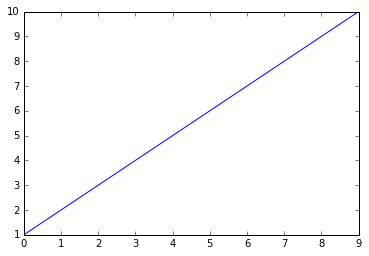

```python
import matplotlib.pyplot as plt
%matplotlib inline

mylist = range(1,11)
plt.plot(mylist)
plt.show()
```

If you pass an iterable to the `plot()` function, matplotlib assumes they are y values and generates the x values for you.

## Labels on a line chart

Draw a line chart with custom title and axis labels.

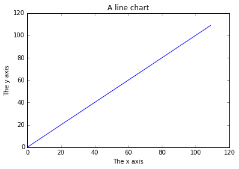

```python
import matplotlib.pyplot as plt
%matplotlib inline
fig, ax = plt.subplots()

plt.plot(range(110), range(110))
ax.set_title('A line chart')
ax.set_xlabel('The x axis')
ax.set_ylabel('The y axis')
```

## NumPy arrays

[NumPy](http://www.numpy.org/) is a Python library that lets you use trigonometry, complex numbers, and more. Use matplotlib to convert all sequences to NumPy arrays.

Create a numpy array.

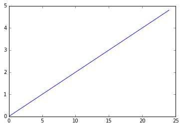

```python
import numpy as np

import matplotlib.pyplot as plt
%matplotlib inline
fig, ax = plt.subplots()

# evenly sample time at 200ms intervals
t = np.arange(0., 5., 0.2)

plt.plot(t)
plt.show()
```

## Multiple ranges

You can show several ranges on the same plot, each with different colors and styles.

Lines are blue by default. You specify colors with the [MathWorks ColorSpec](http://www.mathworks.com/help/matlab/ref/colorspec.html).

You can use either the short name or long name of the color:

```
RGB Value Short Name Long Name
[1 1 0]   y          yellow
[1 0 1]   m          magenta
[0 1 1]   c          cyan
[1 0 0]   r          red
[0 1 0]   g          green
[0 0 1]   b          blue
[1 1 1]   w          white
[0 0 0]   k          black
```

For example, `color='r'` sets the color to red.

Lines are solid by default. You specify shapes, such as dashes, squares, and triangles, with the [LineSpec property](http://www.mathworks.com/help/matlab/ref/linespec.html). To combine a custom color and a custom line shape, you must use the short name of the color.

Create a plot with multiple ranges that have custom colors and shapes.

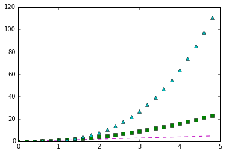

```python
import matplotlib.pyplot as plt
%matplotlib inline
fig, ax = plt.subplots()

import numpy as np

# evenly sample time at 200ms intervals
t = np.arange(0., 5., 0.2)

# magenta dashes (--) for t,
# green squares (s) for t^2
# cyan triangles (^) for t^3
plt.plot(t, t, 'm--', t, t**2, 'gs', t, t**3, 'c^')
plt.show()
```

## Line properties

There are many ways to control line properties with matplotlib.

The [plot() function](http://matplotlib.org/api/pyplot_api.html#matplotlib.pyplot.plot) specifies axes and line formatting. For example:

- Line width: `plt.plot(x, y, linewidth=2.0)`
- Downward-pointing triangle: `line, = plt.plot(x, y, 'v')`
- Multiple x and y pairs: `lines = plt.plot(x1, y1, x2, y2)`

You can turn off antialiasing. For example: `line.set_antialiased(False)`.

The [setp () function](http://matplotlib.org/api/pyplot_api.html#matplotlib.pyplot.setp) sets properties of an object.

The `setp` function can take multiple argument formats. For example:

- MATLAP string value pairs: `plt.setp(lines, color='r', linewidth=2.0)`
- Python arguments: `plt.setp(lines, 'color', 'r', 'linewidth', 2.0)`

## Axes

You can control display properties of axes:

- Titles and lables
- Legends
- Limits
- Scientific notation

### Titles and labels

You can add a title to each axis in a figure. To set the title, use the `set_title` method in the axes instance:

```
ax.set_title("title")
```

Similarly, use the methods `set_xlabel` and `set_ylabel` to set the labels of the X and Y axes:

```
ax.set_xlabel("x")
ax.set_ylabel("y")
```

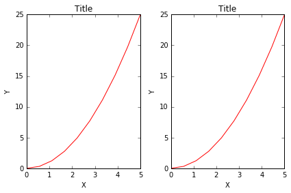

```python
import matplotlib.pyplot as plt
%matplotlib inline
import numpy as np

x = np.linspace(0, 5, 10)
y = x ** 2
fig, axes = plt.subplots(nrows=1, ncols=2)

for ax in axes:
    ax.plot(x, y, 'r')
    ax.set_xlabel('X')
    ax.set_ylabel('Y')
    ax.set_title('Title')

fig.tight_layout()
```

### Legends

Legends for curves in a figure can be added in two ways. One method is to use the MATLAB API `legend` function of the axis object to pass a list of legend texts for the previously defined curves:

```
ax.legend(["curve1", "curve2", "curve3"])
```

Be careful when you use this method: If you add or remove curves from the figure, you must update the `legend` function accordingly.

A more flexible method is to include the `label="label text"` keyword argument for each curve, and include the `legend` method without label name arguments:

```
ax.plot(x, x**2, label="curve1")
ax.plot(x, x**3, label="curve2")
ax.legend()
```

When you add or remove curves to or from the figure, the legend is automatically updated.

The `legend` function takes an optional keyword argument, `loc`, that you can use to specify the location of the legend. The allowed values of `loc` are numerical codes for the various locations. See [Legend location](http://matplotlib.org/users/legend_guide.html#legend-location) for details.

Some of the most common `loc` values are:

```
ax.legend(loc=0) # let matplotlib decide the optimal location
ax.legend(loc=1) # upper right corner
ax.legend(loc=2) # upper left corner
ax.legend(loc=3) # lower left corner
ax.legend(loc=4) # lower right corner
```

Create a plot with a legend.

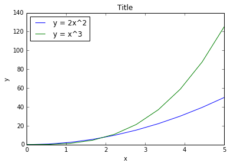

```python
import matplotlib.pyplot as plt
%matplotlib inline
fig, ax = plt.subplots()

import numpy as np

x = np.linspace(0, 5, 10)

ax.plot(x, 2*x**2, label="y = 2x^2")
ax.plot(x, x**3, label="y = x^3")
ax.legend(loc=2); # upper left corner
ax.set_xlabel('x')
ax.set_ylabel('y')
ax.set_title('Title');
```

### Limits

You can set limits on the range of values for axes.

To configure the ranges of the axes, use the `set_ylim` and `set_xlim` functions of the axis object, or use `axis('tight')` function to automatically display "tightly fitted" axis ranges.

Create three plots: one with default ranges, one with tightly-fitted ranges, and one with custom ranges.

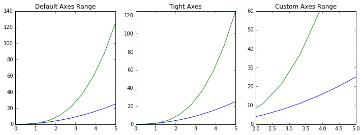

```python
import matplotlib.pyplot as plt
%matplotlib inline
import numpy as np

fig, axes = plt.subplots(1, 3, figsize=(12, 4))
x = np.linspace(0, 5, 10)
axes[0].plot(x, x**2, x, x**3)
axes[0].set_title("Default Axes Range")

axes[1].plot(x, x**2, x, x**3)
axes[1].axis('tight')
axes[1].set_title("Tight Axes")

axes[2].plot(x, np.power(x,2), x, np.power(x,3))
axes[2].set_ylim([0, 60])
axes[2].set_xlim([2, 5])
axes[2].set_title("Custom Axes Range");
```

### Scientific notation

With large numbers on an axis, you might want to use scientific notation. Use the `matplotlib.ticker` module to enable and configure scientific notation.

Create a plot that uses scientific notation for one of the axes.

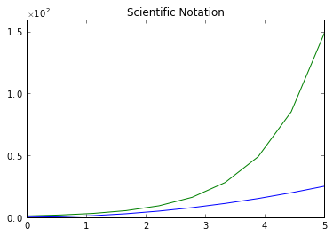

```python
import matplotlib.pyplot as plt
%matplotlib inline
import numpy as np

fig, ax = plt.subplots(1, 1)
x = np.linspace(0, 5, 10)
ax.plot(x, x**2, x, np.exp(x))
ax.set_title("Scientific Notation")

ax.set_yticks([0, 50, 100, 150])

from matplotlib import ticker
formatter = ticker.ScalarFormatter(useMathText=True) #scientific notation
formatter.set_scientific(True)
formatter.set_powerlimits((-1,1))
ax.yaxis.set_major_formatter(formatter)
```

## Multiple plots

Use the `subplot()` function to support multiple plots in the same figure.  
The `subplot()` function parameter has the following arguments:

- number of rows (`nrows`)
- number of columns (`ncols`)
- the plot number (`plot_num`), where the value can be 1 to `nrows * ncols`.

You don't need to include a delimiter between the arguments if `(nrows*ncols)<10`, but you can include commas for readability. For example, `subplot(211)` is equivalent to `subplot(2,1,1)`. If `(nrows*ncols)=>10`, you must include commas between arguments.

In a figure that has 2 rows and 1 column, `subplot(211)` refers to the **first** plot, and `subplot(212)` refers to the **second** plot.

You can create any number of subplots and axes. If you want to place axes manually, instead of on a rectangular grid, use the `axes()` function to specify the location as `axes([left, bottom, width, height])`, where all values are in fractional (0 to 1) coordinates. See an example at [axes_demo.py](http://matplotlib.org/examples/pylab_examples/axes_demo.html).

Create a figure with two plots.

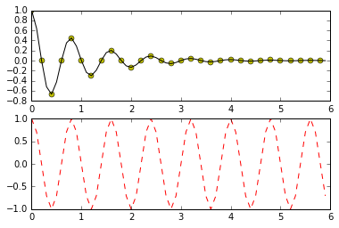

```python
import matplotlib.pyplot as plt
%matplotlib inline
import numpy as np

# define a function to plot, needs numpy
def f(t):
    return np.exp(-t) * np.cos(2.5*np.pi*t)

t1 = np.arange(0.0, 6.0, 0.2)
t2 = np.arange(0.0, 6.0, 0.1)

# '1' parameter is optional, specifying no parameter
# also creates a single plot
plt.figure(1)
plt.subplot(211)
plt.plot(t1, f(t1), 'yo', t2, f(t2), 'k')

plt.subplot(212)
plt.plot(t2, np.cos(2.5*np.pi*t2), 'r--')
plt.show()
```

## Multiple figures

You can create multiple figures by using multiple `figure()` functions with an ascending figure number. Each figure can contain as many axes and subplots as you like.

Create a figure with a subplot and a second figure.

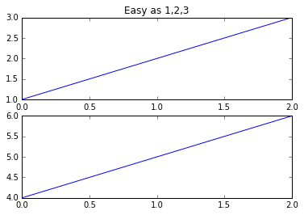

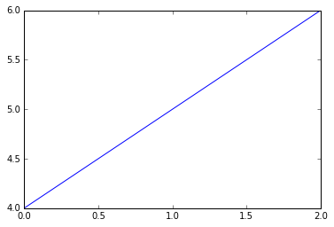

```python
import matplotlib.pyplot as plt
%matplotlib inline
import numpy as np

plt.figure(1)                # the first figure
plt.subplot(211)             # the first subplot in the first figure
plt.plot([1,2,3])
plt.subplot(212)             # the second subplot in the first figure
plt.plot([4,5,6])

plt.figure(2)                # a second figure
plt.plot([4,5,6])            # creates a subplot(111) by default

plt.figure(1)                # figure 1 current; subplot(212) still current
plt.subplot(211)             # make subplot(211) in figure1 current
plt.title('Easy as 1,2,3')   # subplot 211 title
```

## Fonts

You can use LaTex for symbols and alter font properties with the `rcParams` variable:

- Include special characters with LaTex
- Customize fonts with the rcParams variable
- Use STIX fonts with the rcParams variable
- Restore the default font properties

### Include special characters with LaTeX

You can include special characters because matplotlib includes support for LaTeX. To render text as LaTeX, surround the text with dollar sign characters ($), for example: `"$y=x^3$"`.

**Note about using backslash (\):** In LaTeX, you use the backslash to produce the symbols, for example: `$\alpha$`. However, the backslash already has a meaning in Python strings: the escape code character. To properly render the LaTex code, use "raw" text strings. To make a raw text string, add the letter `r` in front of a text string, for example: `r"\alpha"` or `r'\alpha'` instead of `"\alpha"` or `'\alpha'`.

Create a plot with LaTex that uses the alpha character.

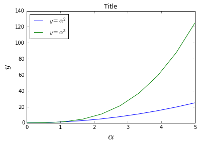

```python
import matplotlib.pyplot as plt
%matplotlib inline
import numpy as np
fig, ax = plt.subplots()
x = np.linspace(0, 5, 10)
ax.plot(x, x**2, label=r"$y = \alpha^2$")
ax.plot(x, x**3, label=r"$y = \alpha^3$")
ax.legend(loc=2) # upper left corner
ax.set_xlabel(r'$\alpha$', fontsize=18)
ax.set_ylabel(r'$y$', fontsize=18)
ax.set_title('Title');
```

### Customize fonts with the rcParams variable

You can change the global font properties, which applies to all text elements in a figure (tick labels, axis labels and titles, legends, and so on), by updating the `rcParams` variable.

Include this code to change the font size to 12 and the font family to serif:

```
import matplotlib as matplotlib
matplotlib.rcParams.update({
    'font.size': 12,
    'font.family': 'serif'
})
```

Create a plot custom font properties.

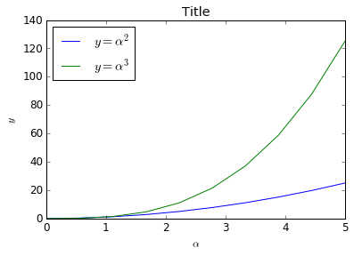

```python
import matplotlib as matplotlib
import matplotlib.pyplot as plt
%matplotlib inline
import numpy as np
fig, ax = plt.subplots()
x = np.linspace(0, 5, 10)
matplotlib.rcParams.update({'font.size': 12, 'font.family': 'serif'})

ax.plot(x, x**2, label=r"$y = \alpha^2$")
ax.plot(x, x**3, label=r"$y = \alpha^3$")
ax.legend(loc=2) # upper left corner
ax.set_xlabel(r'$\alpha$')
ax.set_ylabel(r'$y$')
ax.set_title('Title');
```

### Use STIX fonts with the rcParams variable

A good choice of global fonts are the [STIX fonts](http://www.stixfonts.org/). You specify STIX fonts with the `rcParams` variable.

Create a plot that uses STIX fonts.

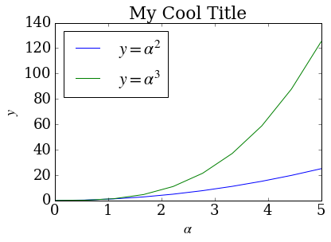

```python
import matplotlib as matplotlib
import matplotlib.pyplot as plt
%matplotlib inline
import numpy as np
fig, ax = plt.subplots()
x = np.linspace(0, 5, 10)
matplotlib.rcParams.update({'font.size': 18, 'font.family': 'STIXGeneral', 'mathtext.fontset': 'stix'})
ax.plot(x, x**2, label=r"$y = \alpha^2$")
ax.plot(x, x**3, label=r"$y = \alpha^3$")
ax.legend(loc=2) # upper left corner
ax.set_xlabel(r'$\alpha$')
ax.set_ylabel(r'$y$')
ax.set_title('My Cool Title');
```

### Restore default font properties

Restore the `rcParams` variable font properties to their defaults.

```python
import matplotlib as matplotlib
matplotlib.rcParams.update({'font.size': 12,
                            'font.family': 'sans',
                            'text.usetex': False})
```

## Scatter plot

Use the `scatter()` function to create a scatterplot.

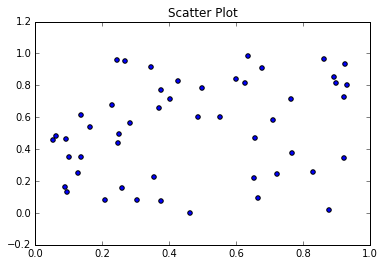

```python
import matplotlib.pyplot as plt
%matplotlib inline
import numpy as np

N= 50
x = np.random.rand(N)  #generate 50 random numbers
y = np.random.rand(N)

plt.scatter(x, y)
plt.title("Scatter Plot")
plt.show()
```

## Step plot

Use the `step()` function to create a step plot.

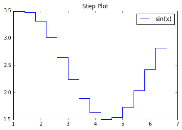

```python
import matplotlib.pyplot as plt
%matplotlib inline
import numpy as np

x = np.arange(1, 7, 0.4)
y0 = np.sin(x)
y = y0.copy() + 2.5

plt.step(x, y, label='sin(x)')
plt.legend()
plt.title("Step Plot")
plt.show()
```

## Vertical bar chart

Use the `bar()` function to create a vertical bar chart.

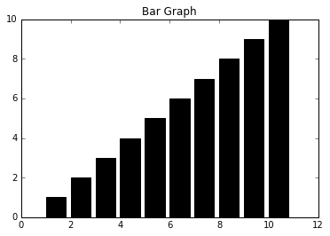

```python
import matplotlib.pyplot as plt
%matplotlib inline
import numpy as np

fig = plt.figure()

x = range(1,11)
y = range(1,11)
plt.bar(x, y, color= 'k')
plt.title("Bar Graph")

plt.show()
```

## Horizontal bar chart

Use the `barh()` function to creat a horizontal bar chart.

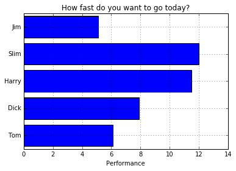

```python
import matplotlib.pyplot as plt
%matplotlib inline
import numpy as np

val = 3+10*np.random.rand(5)    # the bar lengths
pos = np.arange(5)+.5    # the bar centers on the y axis

plt.figure(1)
# plot a horizontal bar chart that is centrally aligned
plt.barh(pos,val, align='center')
# assign names to the y axis, the variables
plt.yticks(pos, ('Tom', 'Dick', 'Harry', 'Slim', 'Jim'))
plt.xlabel('Performance')
plt.title('How fast do you want to go today?')
# add a grid to the background
plt.grid(True)

plt.show()
```

## Stacked bar chart

To create a stacked bar graph, include the `bottom` argument in the `bar()` function. The bottom data represents the bottom coordinate of each data range.

Create a stacked bar chart with the data for men plotted below the data for women.

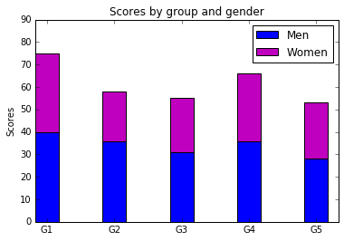

```python
import matplotlib.pyplot as plt
%matplotlib inline
import numpy as np

N = 5
menMeans   = (40, 36, 31, 36, 28)
womenMeans = (35, 22, 24, 30, 25)
menStd     = (2, 3, 4, 1, 2)
womenStd   = (3, 5, 2, 3, 3)
ind = np.arange(N)  # the x locations for the groups
width = 0.35        # the width of the bars: can also be len(x) sequence

p1 = plt.bar(ind, menMeans,   width, color='b')
p2 = plt.bar(ind, womenMeans, width, color='m',
             bottom=menMeans) # specify what's going to the bottom

plt.ylabel('Scores')
plt.title('Scores by group and gender')
plt.xticks(ind+width/2., ('G1', 'G2', 'G3', 'G4', 'G5') )
plt.yticks(np.arange(0,91,10))
plt.legend( (p1[0], p2[0]), ('Men', 'Women') )

plt.show()
```

Create a stacked bar chart that shows the data for women plotted below the data for men.

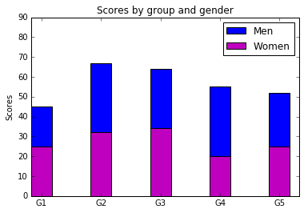

```python
import matplotlib.pyplot as plt
%matplotlib inline
import numpy as np

N = 5
menMeans   = (20, 35, 30, 35, 27)
womenMeans = (25, 32, 34, 20, 25)
menStd     = (2, 3, 4, 1, 2)
womenStd   = (3, 5, 2, 3, 3)
ind = np.arange(N)    # the x locations for the groups
width = 0.35          # the width of the bars: can also be len(x) sequence

p1 = plt.bar(ind, menMeans,   width, color='b', bottom= womenMeans) # specify what's going to the bottom
p2 = plt.bar(ind, womenMeans, width, color='m')

plt.ylabel('Scores')
plt.title('Scores by group and gender')
plt.xticks(ind+width/2., ('G1', 'G2', 'G3', 'G4', 'G5') )
plt.yticks(np.arange(0,91,10))
plt.legend( (p1[0], p2[0]), ('Men', 'Women') )

plt.show()
```

## Error bars

Use the `errorbar()` function and its `xerr` and `yerr` arguments to specify error margins. The error bar is a vertical line that looks like this `|----|` and indicates a margin of error above and below the y values.

Create a bar chart with error bars.

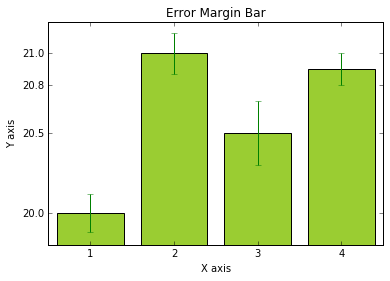

```python
import matplotlib.pyplot as plt
%matplotlib inline
import numpy as np

x = [1, 2, 3, 4]
y = [20, 21 , 20.5, 20.9]

#define how much the error
y_error = [.12, .13, .2, .1]

#plot data
plt.bar(x,y, color="yellowgreen", align='center')
plt.errorbar(x,y, yerr=y_error, linestyle="None",
             marker="None", color="green")

#configure  X axis
plt.xlim(0.5, 4.5)
plt.xticks([1,2,3,4])
#configure Y axis
plt.ylim(19.8,21.2)
plt.yticks([20,21,20.5,20.8])

#title and labels
plt.xlabel("X axis")
plt.ylabel("Y axis")
plt.title("Error Margin Bar")

#show plot
plt.show()
```

Create a line plot with error bars.

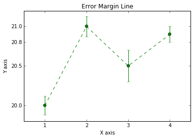

```python
import matplotlib.pyplot as plt
%matplotlib inline
import numpy as np

x = [1, 2, 3, 4]
y = [20, 21 , 20.5, 20.9]

#errors
y_error = [.12, .13, .2, .1]

#plot data
plt.plot(x,y, linestyle="dashed", marker="o", color="green")
plt.errorbar(x,y, yerr=y_error, linestyle="None",
             marker="None", color="green")

#configure  X axis
plt.xlim(0.5, 4.5)
plt.xticks([1,2,3,4])
#configure Y axis
plt.ylim(19.8,21.2)
plt.yticks([20,21,20.5,20.8])

#title and labels
plt.xlabel("X axis")
plt.ylabel("Y axis")
plt.title("Error Margin Line")
#show plot
plt.show()
```

## Fill between boundaries

You can generate a shaded region between a minimum and maximum boundary to highlight ranges by using the `fill_between()` function. Use the `where` parameter to fill in logical ranges, for exmaple, to fill in a curve over a threshold value. You can fill ranges in subplots, too.

Create a plot with a filled range.

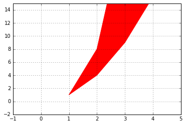

```python
import matplotlib.pyplot as plt
%matplotlib inline
import numpy as np

plt.fill_between(x, np.power(x,2), np.power(x,3), color="red")
plt.ylim(-2,15)
plt.xlim(-1,5)
plt.grid(True)
plt.show()
```

Create a plot with two filled subplots.

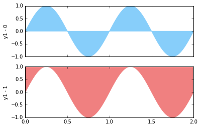

```python
import matplotlib.pyplot as plt
%matplotlib inline
import numpy as np

x = np.arange(0.0, 2, 0.01)
y1 = np.sin(2*np.pi*x)

width = 0.35

fig, (ax1, ax2) = plt.subplots(2,1, sharex=True)

ax1.fill_between(x, 0, y1, color="lightskyblue")
ax1.set_ylabel('y1 - 0')

ax2.fill_between(x, y1, 1, color="lightcoral")
ax2.set_ylabel('y1 - 1')

plt.show()
```

## Histogram

Create a subplot with a default histogram and a subplot with a cumulative histogram.

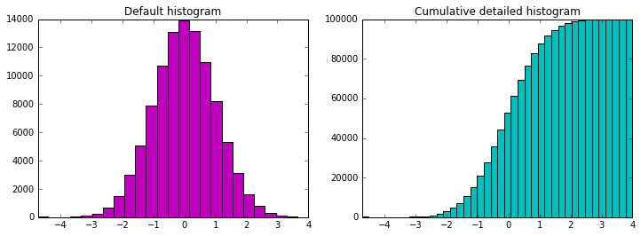

```python
import matplotlib.pyplot as plt
%matplotlib inline
import numpy as np

n = np.random.randn(100000)
fig, axes = plt.subplots(1, 2, figsize=(12,4))

axes[0].hist(n, bins=25, color = 'm')
axes[0].set_title("Default histogram")
axes[0].set_xlim((min(n), max(n)))

axes[1].hist(n, cumulative=True, bins=40, color='c')
axes[1].set_title("Cumulative detailed histogram")
axes[1].set_xlim((min(n), max(n)));
```

## Pie chart

You can create a pie chart with the `pie()` function. By default, this function chooses its own colors, and does not display legends or label names. You can set colors, legends, labels, the starting angle, shadowing, and whether any section is exploded, with the `pie()` function parameters.

The default starting angle is 0, which starts the first slice on the x-axis. If you set `startangle=90`, everything is rotated counter-clockwise by 90 degrees, so that the plotting starts on the positive y-axis.

Create a pie chart with custom colors, labels, and starting angle.

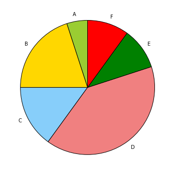

```python
import matplotlib.pyplot as plt
%matplotlib inline
import numpy as np

data = [5,20,15,40,10,10]
labels = ['A','B','C','D','E','F']
plt.figure(1, figsize=(6,6))  # make it square
colors = ['yellowgreen', 'gold', 'lightskyblue',
          'lightcoral', 'green', 'red']
plt.pie(data, labels=labels, colors= colors, startangle=90)

plt.show()
```

Create a pie chart with labels, an exploded view, a shadow effect, a custom starting angle, and a title.

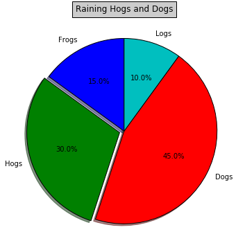

```python
import matplotlib.pyplot as plt
%matplotlib inline
import numpy as np

plt.figure(1, figsize=(6,6))

# The slices are ordered and plotted counter-clockwise.
# The second slice is exploded and shadowed.
labels = 'Frogs', 'Hogs', 'Dogs', 'Logs'
fracs = [15, 30, 45, 10]
explode=(0, 0.05, 0, 0)

plt.pie(fracs, explode=explode, labels=labels,
                autopct='%1.1f%%', shadow=True, startangle=90)

plt.title('Raining Hogs and Dogs', bbox={'facecolor':'0.8', 'pad':5})

plt.show()
```

## Polar plot

You can create these kind of polar plots by including the `polar=True` argument:

- Polar line plot
- Polar bar plot
- Polar scatter plot

### Polar line plot

Create a polar line plot.

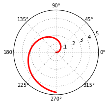

```python
import matplotlib.pyplot as plt
%matplotlib inline
import numpy as np

fig = plt.figure()
ax = fig.add_axes([0.0, 0.0, .6, .6], polar=True)
t = np.linspace(0, 1.5 * np.pi, 100)
ax.plot(t, t, color='red', lw=3);
```

### Polar bar plot

Create a polar bar plot.

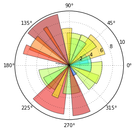

```python
import matplotlib.pyplot as plt
%matplotlib inline
import numpy as np

N = 21
theta = np.linspace(0.0, 2 * np.pi, N, endpoint=False)
radii = 10 * np.random.rand(N)
width = np.pi / 4 * np.random.rand(N)

ax = plt.subplot(111, polar=True) #polar=True for polar plot
bars = ax.bar(theta, radii, width=width, bottom=0.0)

# Use custom colors and opacity
for r, bar in zip(radii, bars):
    bar.set_facecolor(plt.cm.jet(r / 10.))
    bar.set_alpha(0.5)

plt.show()
```

### Polar scatter plot

Create a polar scatter plot.

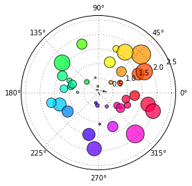

```python
import matplotlib.pyplot as plt
%matplotlib inline
import numpy as np

N = 50
r = 2 * np.random.rand(N)
theta = 2 * np.pi * np.random.rand(N)
area = 200 * r**2 * np.random.rand(N)
colors = theta

ax = plt.subplot(111, polar=True)
c = plt.scatter(theta, r, c=colors, s=area, cmap=plt.cm.hsv)
c.set_alpha(0.75)

plt.show()
```